# Analysis of the Impact of Strategy Design Pattern on Maintainability

This study hypothesize that the Strategy design pattern impacts on the effectiveness required to maintain Java applications. This document summarises results of this study and provides R commands used to produce the analysis.

## 1. Preliminary Procedures

These procedures consists of importing the data set into R environment, activating libraries, and organising data for performing analyses.

### 1.1. Importing dataset

- *observations* consists of experiment observations for correctness - a measure of effectiveness. The dataset includes additional classification information, such as the order tasks were applied to participants;
- *participants* consists of demographic data of participants;
- *feedback* consists of perceptions of participants on experiment conditions.

```r
# Setting up current directory
setwd ("/Users/gabriel/Documents/Production/Empirical research/Experimentation/2018 - Strategy pattern on DAO maintainability/Datasets/SANER-2020")

# Original data set
observations <- read.csv ("observations.csv", header=T, sep=",")
participants <- read.csv ("participants.csv", header=T, sep=";")
feedback <- read.csv ("feedback.csv", header=T, sep=";")
```

> The dataset variables

```r
names (observations)
```

```
## [1] "id"         "treatment"  "task"       "task_order" "correct"
## [6] "sql_issues"
```

```r
names (participants)
```

```
##  [1] "id"                    "age"
##  [3] "genre"                 "languages"
##  [5] "languages_category"    "java_fluency"
##  [7] "java_fluency_category" "modify"
##  [9] "experience"            "work"
## [11] "patterns"
```

```r
names (feedback)
```

```
## [1] "id"              "ease_experiment" "easiest_model"   "benefit_dao"
```

### 1.2. Activating libraries

These are additional libraries used to specific data analysis.

```r
library ("sqldf")       # Used for analysing data
```

```
## Could not load tcltk.  Will use slower R code instead.
```

```r
library ("plyr")        # Used for summarising datasets
library ("ggplot2")     # Used for creating plots
library ("scales")      # Used for formatting plot text
library ("gmodels")     # Used for calculating Crosstable
library ("exact2x2")    # Used for calculating McNemar's exact test
```

### 1.3. Subsetting datesets

```r
observations.nopretest <- sqldf('SELECT *
                                 FROM `observations`
                                 WHERE task == "post-test"')

observations.nopretest.traditional <- sqldf('SELECT *
                                             FROM `observations.nopretest`
                                             WHERE treatment == "traditional"')

observations.nopretest.strategy <- sqldf('SELECT *
                                          FROM `observations.nopretest`
                                          WHERE treatment == "strategy"')

observations.traditional <- sqldf('SELECT *
                                   FROM `observations`
                                   WHERE treatment == "traditional"')

observations.strategy <- sqldf('SELECT *
                                FROM `observations`
                                WHERE treatment == "strategy"')

observations.nopretest.work <- sqldf('SELECT *
                                     FROM `observations.nopretest` as observations
                                     INNER JOIN `participants` as participants
                                     ON observations.id == participants.id
                                     WHERE participants.work == "yes"')

observations.nopretest.nowork <- sqldf('SELECT *
                                     FROM `observations.nopretest` as observations
                                     INNER JOIN `participants` as participants
                                     ON observations.id == participants.id
                                     WHERE participants.work == "no"')

observations.nopretest.experiencedp <-sqldf('SELECT *
                                                FROM `observations.nopretest` as observations
                                                INNER JOIN `participants` as participants
                                                ON observations.id == participants.id
                                                WHERE participants.patterns == "yes"')

observations.nopretest.noexperiencedp <-sqldf('SELECT *
                                                FROM `observations.nopretest` as observations
                                                INNER JOIN `participants` as participants
                                                ON observations.id == participants.id
                                                WHERE participants.patterns == "no"')
```

## 2. Participant Characterisation Analysis

### 2.1. Age

> Plot

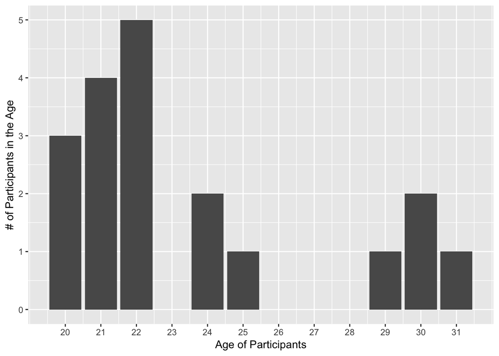

```r
# Summarising data for plotting
participant.age.df <- ddply(participants,
                            ~age,
                            summarise,
                            count = length (age))

# Ploting data
ggplot(
  participant.age.df,
  aes
    (
      y = count,
      x = age
      )
  ) +
  geom_histogram(
    stat = "identity"
  ) +
  theme(
    legend.title = element_blank(),
    plot.title = element_text(hjust = 0.5, margin = margin(15, 0, 15, 0))
  ) +
  labs(
    x="Age of Participants",
    y="# of Participants in the Age"
  ) +
  scale_y_continuous (breaks=c(0:5)) +
  scale_x_continuous (breaks=c(20:31))
```

> Analysis
- Regarding age, our participants can be grouped into two categories. Whereas most participants (73.7%) are between 20 and 24, the five remaining participants (26.3%) are between 25 and 31. The young age is expected since our participants are undergraduates. In the StackOverflow 2018 developer survey, participants within the same range of ours represent the majority of professional developers that took part in their survey. However, in the StackOverflow survey, participants between 18 and 24 years old represent the second most common category whereas participants between 25 and 34 years old represent the first most common category. In addition, our participants are slightly younger (23.5) than Brazilian participants in the StackOverflow survey (25.0).

### 2.2. Gender

> Plot

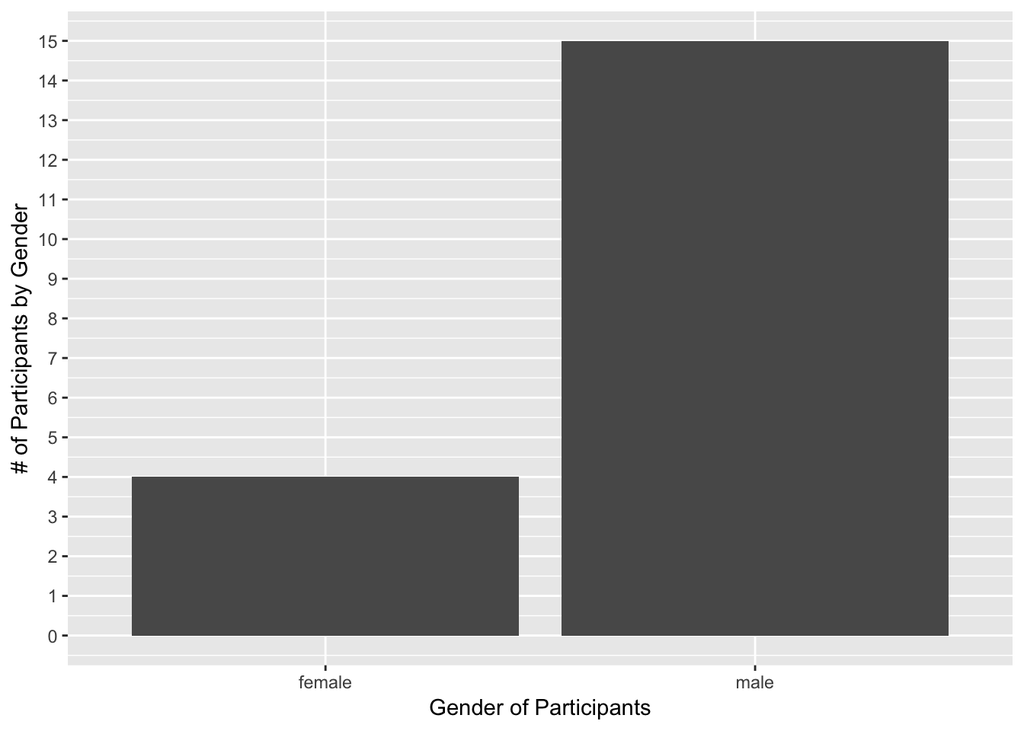

```r
# Summarising data for plotting
participant.gender.df <- ddply(participants,
                            ~genre,
                            summarise,
                            count = length (genre))

# Ploting data
ggplot(
  participant.gender.df,
  aes
    (
      y = count,
      x = genre
      )
  ) +
  geom_histogram(
    stat = "identity"
  ) +
  theme(
    legend.title = element_blank(),
    plot.title = element_text(hjust = 0.5, margin = margin(15, 0, 15, 0))
  ) +
  labs(
    x="Gender of Participants",
    y="# of Participants by Gender"
  ) +
  scale_y_continuous (breaks=c(0:15))
```

> Analysis
- Regarding gender, our participants differ significantly from professional developers in the StackOverflow 2018 survey. Although most of our participants are male (78.9%) like in the survey, our female participants (21.1%) are far more representative than female developers in the StackOverflow 2018 survey (6.7%). Since our participants are undergraduates, we checked the [Brazilian higher education census](http://portal.inep.gov.br/web/guest/resumos-tecnicos1), which shows that our participants also differ from common gender distribution in Brazilian higher education.

### 2.3. Employment

> Plot

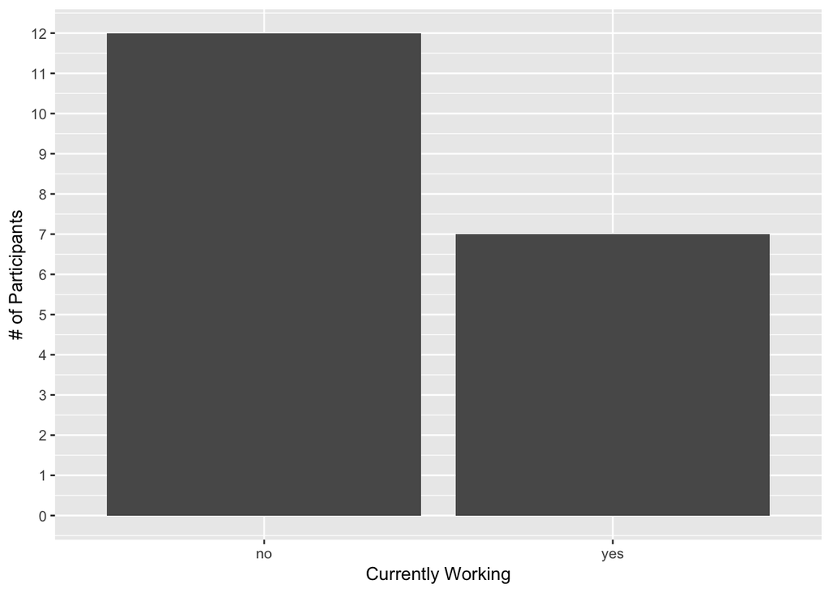

```r
# Summarising data for plotting
participant.working.df <- ddply(participants,
                                ~work,
                                summarise,
                                count = length (work))

# Ploting data
ggplot(
  participant.working.df,
  aes
    (
      y = count,
      x = work
      )
  ) +
  geom_histogram(
    stat = "identity"
  ) +
  theme(
    legend.title = element_blank(),
    plot.title = element_text(hjust = 0.5, margin = margin(15, 0, 15, 0))
  ) +
  labs(
    x="Currently Working",
    y="# of Participants"
  ) +
  scale_y_continuous (breaks=c(0:12))
```

> Follow-up

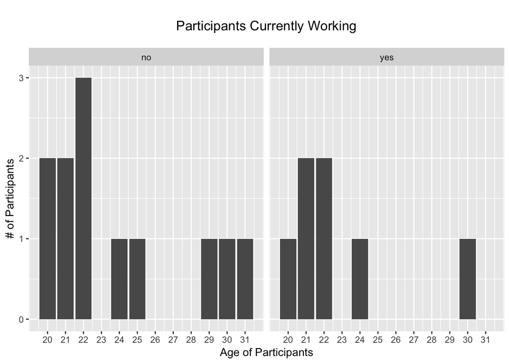

```r
# Summarising data for plotting
participant.age.working.df <- ddply(participants,
                                    work~age,
                                    summarise,
                                    count = length (age))

# Ploting data
ggplot(
  participant.age.working.df,
  aes
    (
      y = count,
      x = age
      )
  ) +
  geom_histogram(
    stat = "identity"
  ) +
  facet_wrap(
    ~work
  ) +
  theme(
    legend.title = element_blank(),
    plot.title = element_text(hjust = 0.5, margin = margin(15, 0, 15, 0))
  ) +
  ggtitle ("Participants Currently Working") +
  labs(
    x="Age of Participants",
    y="# of Participants"
  ) +
  scale_y_continuous (breaks=c(0:5)) +
  scale_x_continuous (breaks=c(20:31))
```

> Analysis
- Most of our participants (63.1%) are currently unemployed unlike the StackOverflow survey whereby unemployment among professional developers is about 8%. The additional plot suggests that employment is related to participant’s age in that 42.9% of younger partipants are currently working whereas 20% of older participants are currently working.

### 2.4. Previous Experience on Design Patterns

> Plot

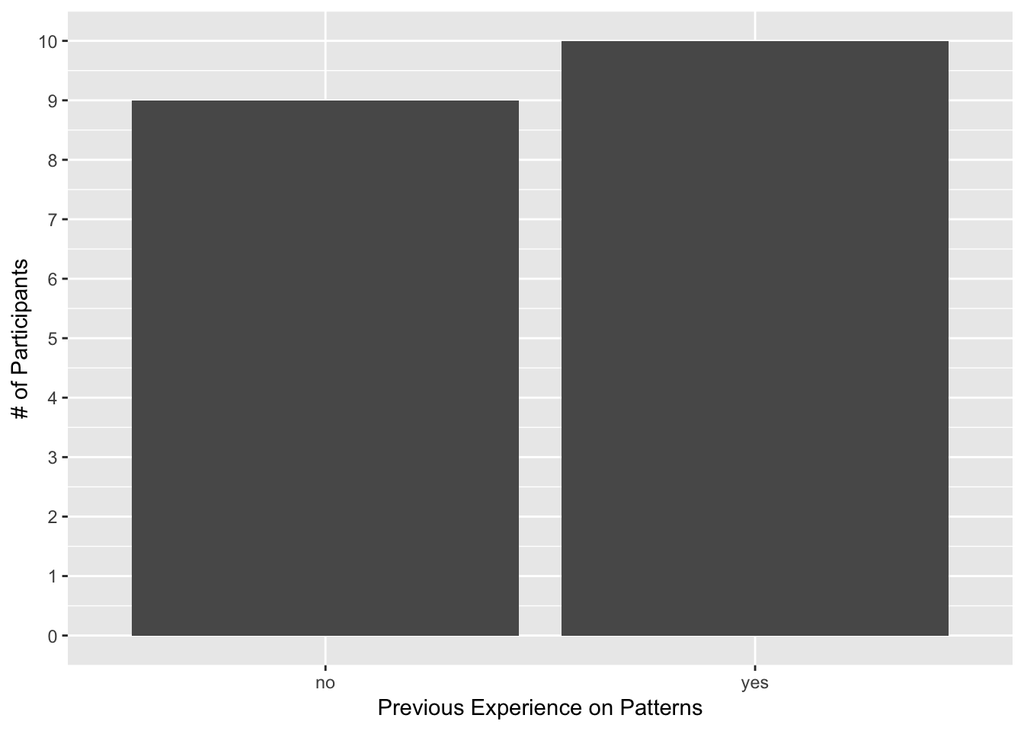

```r
# Summarising data for plotting
participant.patterns.df <- ddply(participants,
                                ~patterns,
                                summarise,
                                count = length (patterns))

# Ploting data
ggplot(
  participant.patterns.df,
  aes
    (
      y = count,
      x = patterns
      )
  ) +
  geom_histogram(
    stat = "identity"
  ) +
  theme(
    legend.title = element_blank(),
    plot.title = element_text(hjust = 0.5, margin = margin(15, 0, 15, 0))
  ) +
  labs(
    x="Previous Experience on Patterns",
    y="# of Participants"
  ) +
  scale_y_continuous (breaks=c(0:12))
```

> Follow-up

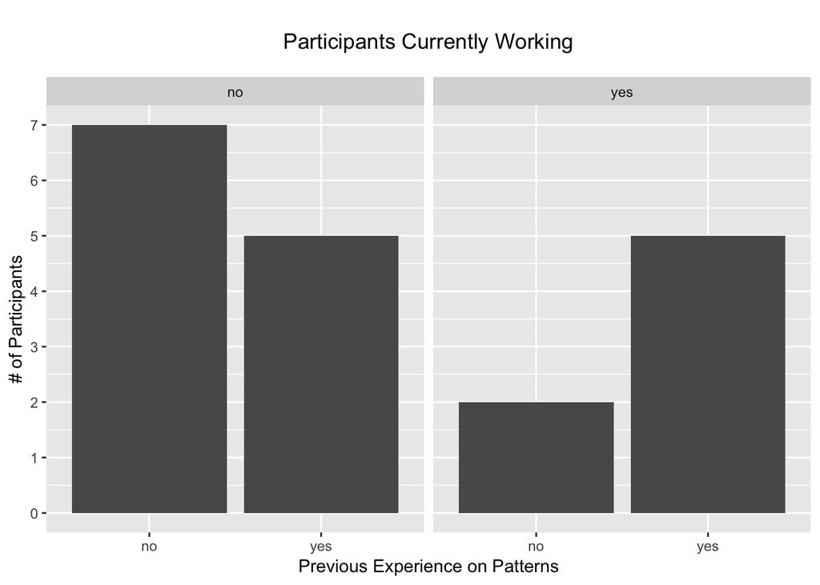

```r
# Summarising data for plotting
participant.patterns.work.df <- ddply(participants,
                                      work~patterns,
                                      summarise,
                                      count = length (patterns))

# Ploting data
ggplot(
  participant.patterns.work.df,
  aes
    (
      y = count,
      x = patterns
      )
  ) +
  geom_histogram(
    stat = "identity"
  ) +
  facet_wrap(
    ~work
  ) +
  theme(
    legend.title = element_blank(),
    plot.title = element_text(hjust = 0.5, margin = margin(15, 0, 15, 0))
  ) +
  ggtitle ("Participants Currently Working") +
  labs(
    x="Previous Experience on Patterns",
    y="# of Participants"
  ) +
  scale_y_continuous (breaks=c(0:12))
```

> Analysis
- The rate of participants with (52.6%) and without (47.4%) previous experience on patterns is nearly fifty-fifty, differing by only one participant. This result clearly shows two categories of participants that could differ in their performance when executing our experimental task. The additional plot suggests that previous experience on pattern is related to working condition.

### 2.5. Programming Experience

> Plot

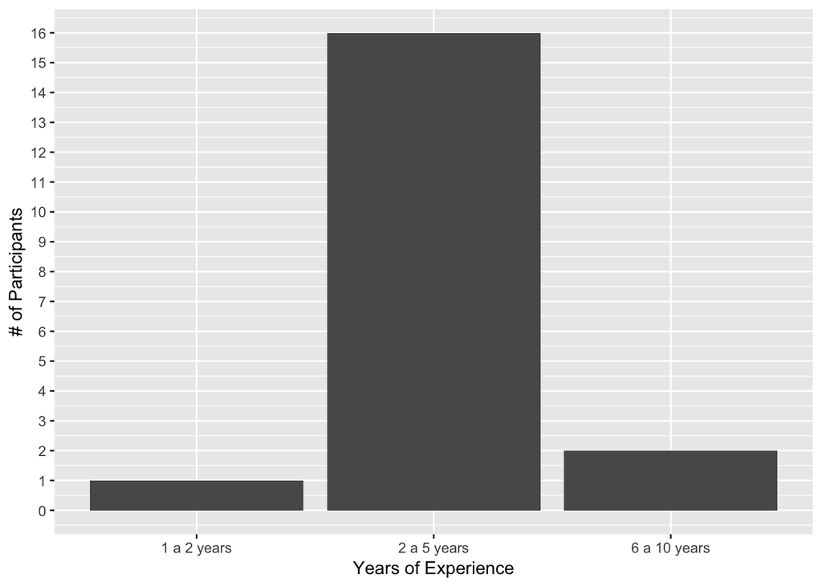

```r
# Summarising data for plotting
participant.experience.df <- ddply(participants,
                                  ~experience,
                                  summarise,
                                  count = length (experience))

# Ploting data
ggplot(
  participant.experience.df,
  aes
    (
      y = count,
      x = experience
      )
  ) +
  geom_histogram(
    stat = "identity"
  ) +
  theme(
    legend.title = element_blank(),
    plot.title = element_text(hjust = 0.5, margin = margin(15, 0, 15, 0))
  ) +
  labs(
    x="Years of Experience",
    y="# of Participants"
  ) +
  scale_y_continuous (breaks=c(0:16))
```

> Analysis
- Most of our participants (84.2%) have between 2 and 5 years of coding experience. This result is not surprising given the young age of our participants. In the StackOverflow 2018 survey, 24.4% professional developers have between 3 to 5 years of coding experience.

### 2.6. Java Fluency

> Plot

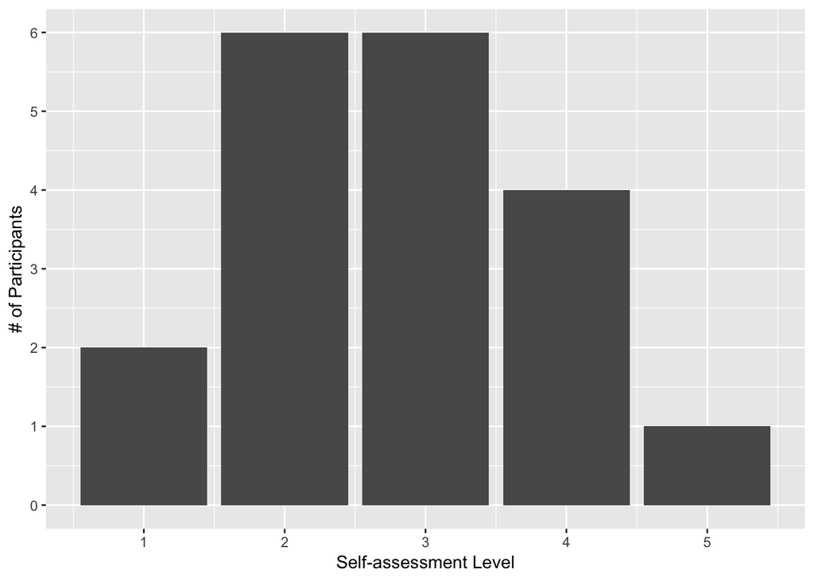

```r
# Summarising data for plotting
participant.java.df <- ddply(participants,
                             ~java_fluency,
                             summarise,
                             count = length (java_fluency))

# Ploting data
ggplot(
  participant.java.df,
  aes
    (
      y = count,
      x = java_fluency
      )
  ) +
  geom_histogram(
    stat = "identity"
  ) +
  theme(
    legend.title = element_blank(),
    plot.title = element_text(hjust = 0.5, margin = margin(15, 0, 15, 0))
  ) +
  labs(
    x="Self-assessment Level",
    y="# of Participants"
  ) +
  scale_y_continuous (breaks=c(0:6))
```

> Analysis
- No student selected zero in the self-assessment of Java programming level of expertise, which qualified all students to take part in our study. Levels 2 (31.6%) and 3 (31.6%) were the most selected ones whereas only one participant (5.2%) selected level 5. These differences may lead to different results in our study.

## 3. Effectiveness Analysis

This section analyses effectiveness differences between traditional and strategy treatments.

### 3.1. Summary

> Plot

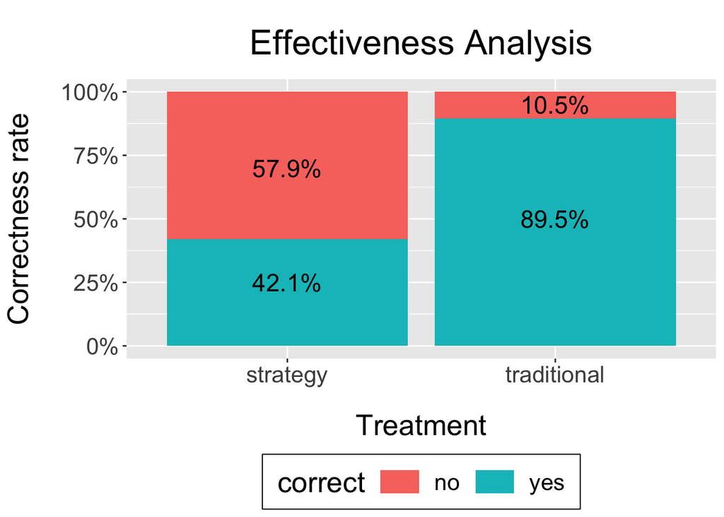

```r
# Summarising data for plotting
correctness.traditional <- ddply(observations.nopretest.traditional,
                                 treatment ~ correct,
                                 summarise,
                                 correctness = round((length (correct) / 19 * 100), digits = 1))

correctness.strategy <- ddply(observations.nopretest.strategy,
                              treatment ~ correct,
                              summarise,
                              correctness = round((length (correct) / 19 * 100), digits = 1))

correctness.df <- rbind (correctness.traditional,
                         correctness.strategy)

# Ploting data
ggplot(
  correctness.df,
  aes
    (
      y = correctness,
      x = treatment,
      fill = correct
      )
  ) +
  geom_bar(
    stat="identity",
    position = "stack"
  )  +
  ggtitle ("Effectiveness Analysis") +
  theme(
    plot.title = element_text(hjust = 0.5, margin = margin(15, 0, 15, 0)),
    axis.title.y = element_text (margin = margin (0, 20, 0, 0)),
    axis.title.x = element_text (margin = margin (20, 0, 0, 0)),
    legend.position = "bottom",
    legend.box.background = element_rect(),
    legend.box.margin = margin (5, 5, 5, 5),
    legend.key.width = unit (1, "cm"),
    text = element_text(size=20)
    # text = element_text(size=40)
  ) +
  geom_text(
    aes(
      x = treatment,
      y = c (95, 50, 70, 25),
      label = paste0(correctness,"%")
    ),
    size=6
    # size=12
  ) +
  labs(
    x="Treatment",
    y="Correctness rate"
  ) +
  scale_y_continuous(labels = dollar_format (suffix = "%", prefix = ""))
```

> Inferential Statistics

```r
# Odds ratio
odds.table <- table (sqldf('SELECT
                                  treatment,
                                  correct
                              FROM `observations.nopretest`'))

CrossTable(odds.table,
           fisher = TRUE,
           chisq = TRUE,
           expected = FALSE)
```

```
##
##
##    Cell Contents
## |-------------------------|
## |                       N |
## | Chi-square contribution |
## |           N / Row Total |
## |           N / Col Total |
## |         N / Table Total |
## |-------------------------|
##
##
## Total Observations in Table:  38
##
##
##              | correct
##    treatment |        no |       yes | Row Total |
## -------------|-----------|-----------|-----------|
##     strategy |        11 |         8 |        19 |
##              |     3.115 |     1.620 |           |
##              |     0.579 |     0.421 |     0.500 |
##              |     0.846 |     0.320 |           |
##              |     0.289 |     0.211 |           |
## -------------|-----------|-----------|-----------|
##  traditional |         2 |        17 |        19 |
##              |     3.115 |     1.620 |           |
##              |     0.105 |     0.895 |     0.500 |
##              |     0.154 |     0.680 |           |
##              |     0.053 |     0.447 |           |
## -------------|-----------|-----------|-----------|
## Column Total |        13 |        25 |        38 |
##              |     0.342 |     0.658 |           |
## -------------|-----------|-----------|-----------|
##
##
## Statistics for All Table Factors
##
##
## Pearson's Chi-squared test
## ------------------------------------------------------------
```

[output cut: 10 more lines]

```
##
## Alternative hypothesis: true odds ratio is not equal to 1
## p =  0.005137268
## 95% confidence interval:  1.773571 123.7429
##
## Alternative hypothesis: true odds ratio is less than 1
## p =  0.9998182
## 95% confidence interval:  0 83.15492
##
## Alternative hypothesis: true odds ratio is greater than 1
## p =  0.002568634
## 95% confidence interval:  2.20826 Inf
##
##
##
```

```r
# Preparing data to significance and importance tests
experiment <- sqldf('SELECT
                      correct
                    FROM
                    `observations.nopretest`
                    WHERE
                     treatment = "strategy"')


control <- sqldf('SELECT
                    correct
                 FROM
                 `observations.nopretest`
                 WHERE
                  treatment = "traditional"')

inferentialEffectiveness <- cbind (experiment, control)

names (inferentialEffectiveness) <- c("experiment", "control")

# Inference test
CrossTable(table (inferentialEffectiveness),
           chisq = FALSE)
```

```
##
##
##    Cell Contents
## |-------------------------|
## |                       N |
## | Chi-square contribution |
## |           N / Row Total |
## |           N / Col Total |
## |         N / Table Total |
## |-------------------------|
##
##
## Total Observations in Table:  19
##
##
##              | control
##   experiment |        no |       yes | Row Total |
## -------------|-----------|-----------|-----------|
##           no |         2 |         9 |        11 |
##              |     0.612 |     0.072 |           |
##              |     0.182 |     0.818 |     0.579 |
##              |     1.000 |     0.529 |           |
##              |     0.105 |     0.474 |           |
## -------------|-----------|-----------|-----------|
##          yes |         0 |         8 |         8 |
##              |     0.842 |     0.099 |           |
##              |     0.000 |     1.000 |     0.421 |
##              |     0.000 |     0.471 |           |
##              |     0.000 |     0.421 |           |
## -------------|-----------|-----------|-----------|
## Column Total |         2 |        17 |        19 |
##              |     0.105 |     0.895 |           |
## -------------|-----------|-----------|-----------|
##
##
```

```r
mcnemar.exact(table (inferentialEffectiveness))
```

```
##
##  Exact McNemar test (with central confidence intervals)
##
## data:  table(inferentialEffectiveness)
## b = 9, c = 0, p-value = 0.003906
## alternative hypothesis: true odds ratio is not equal to 1
## 95 percent confidence interval:
##  1.973826      Inf
## sample estimates:
## odds ratio
##        Inf
```

> Analysis
- Strategy condition presented significantly more implementation errors than traditional condition;

### 3.2. Task Order Analysis

> Plot

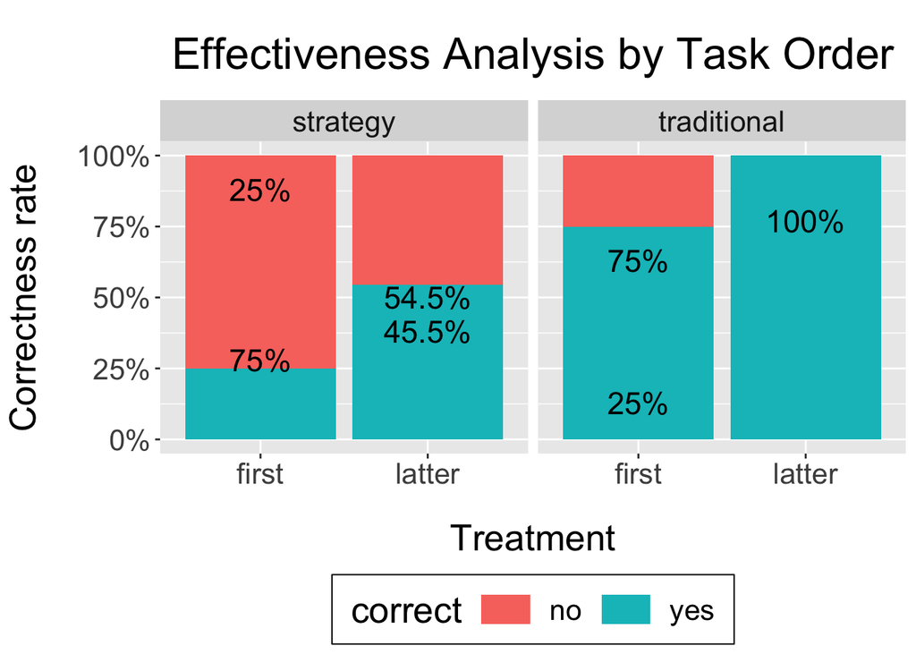

```r
# Summarising data for plotting

## Calculating correctness rate for first
correctness.nopretest.traditional.first <- ddply(sqldf ('SELECT * FROM `observations.nopretest.traditional` WHERE task_order = "first"'),
                                              task_order ~ treatment ~ correct,
                                              summarise,
                                              correctness = round ((length(correct) / 8) * 100, 1))

correctness.nopretest.strategy.first <- ddply(sqldf ('SELECT * FROM `observations.nopretest.strategy` WHERE task_order = "first"'),
                                              task_order ~ treatment ~ correct,
                                              summarise,
                                              correctness = round ((length(correct) / 8) * 100, 1))


## Calculating correctness rate for second
correctness.nopretest.traditional.latter <- ddply(sqldf ('SELECT * FROM `observations.nopretest.traditional` WHERE task_order = "latter"'),
                                              task_order ~ treatment ~ correct,
                                              summarise,
                                              correctness = round ((length(correct) / 11) * 100, 1))

correctness.nopretest.strategy.latter <- ddply(sqldf ('SELECT * FROM `observations.nopretest.strategy` WHERE task_order = "latter"'),
                                              task_order ~ treatment ~ correct,
                                              summarise,
                                              correctness = round ((length(correct) / 11) * 100, 1))

## Merging all summaries to create a single dataset
correctness.task_order.df <- rbind (correctness.nopretest.traditional.first,
                                    correctness.nopretest.traditional.latter,
                                    correctness.nopretest.strategy.first,
                                    correctness.nopretest.strategy.latter)

# Ploting data
ggplot(
  correctness.task_order.df,
  aes
    (
      y = correctness,
      x = task_order,
      fill = correct
      )
  ) +
  geom_bar(
    stat="identity",
    position = "stack"
  )  +
  facet_wrap (
    ~treatment
  ) +
  geom_text(
    aes(
      x = task_order,
      y = c (13, 63, 77, 28, 88, 38, 50),
      label = paste0(correctness,"%")
    ),
    size=6
    # size=12
  ) +
theme(
    plot.title = element_text(hjust = 0.5, margin = margin(15, 0, 15, 0)),
    axis.title.y = element_text (margin = margin (0, 20, 0, 0)),
    axis.title.x = element_text (margin = margin (20, 0, 0, 0)),
    legend.position = "bottom",
    legend.box.background = element_rect(),
    legend.box.margin = margin (5, 5, 5, 5),
    legend.key.width = unit (1, "cm"),
    text = element_text(size=20)
    # text = element_text(size=40)
  ) +
  ggtitle ("Effectiveness Analysis by Task Order") +
  labs(
    x="Treatment",
    y="Correctness rate"
  ) +
  scale_y_continuous(labels = dollar_format (suffix = "%", prefix = ""))
```

```r
# Summarising observations in the plot
print ("-- Observations in the plot --- ")
```

```
## [1] "-- Observations in the plot --- "
```

```r
ddply(observations.nopretest,
      treatment~task_order,
      summarise,
      count = length (task_order))
```

```
##     treatment task_order count
## 1    strategy      first     8
## 2    strategy     latter    11
## 3 traditional      first     8
## 4 traditional     latter    11
```

### 3.3. Pretest Analysis

> Plot

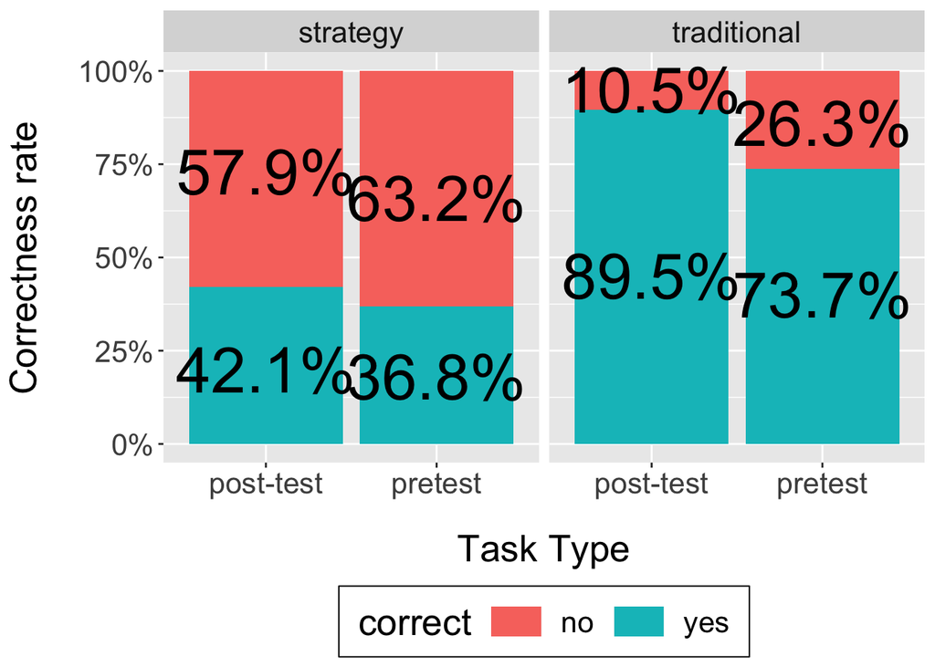

```r
# Summarising data for plotting

## Calculating correctness rate for first
correctness.traditional.pre <- ddply(sqldf ('SELECT * FROM `observations.traditional` WHERE task = "pretest"'),
                                              task ~ treatment ~ correct,
                                              summarise,
                                              correctness = round ((length(correct) / 19) * 100, 1))

correctness.strategy.pre <- ddply(sqldf ('SELECT * FROM `observations.strategy` WHERE task = "pretest"'),
                                              task ~ treatment ~ correct,
                                              summarise,
                                              correctness = round ((length(correct) / 19) * 100, 1))


## Calculating correctness rate for second
correctness.traditional.post <- ddply(sqldf ('SELECT * FROM `observations.traditional` WHERE task = "post-test"'),
                                              task ~ treatment ~ correct,
                                              summarise,
                                              correctness = round ((length(correct) / 19) * 100, 1))

correctness.strategy.post <- ddply(sqldf ('SELECT * FROM `observations.strategy` WHERE task = "post-test"'),
                                              task ~ treatment ~ correct,
                                              summarise,
                                              correctness = round ((length(correct) / 19) * 100, 1))

## Merging all summaries to create a single dataset
correctness.prepost.df <- rbind (correctness.traditional.pre,
                                    correctness.strategy.pre,
                                    correctness.traditional.post,
                                    correctness.strategy.post)

# Ploting data
ggplot(
  correctness.prepost.df,
  aes
    (
      y = correctness,
      x = task,
      fill = correct
      )
  ) +
  geom_bar(
    stat="identity",
    position = "stack"
  )  +
  facet_wrap (
    ~treatment
  ) +
  geom_text(
    aes(
      x = task,
      y = c (86, 40, 66, 18, 95, 45, 73, 20),
      label = paste0(correctness,"%")
    ),
    # size=6
    size=12
  ) +
theme(
    plot.title = element_text(hjust = 0.5, margin = margin(15, 0, 15, 0)),
    axis.title.y = element_text (margin = margin (0, 20, 0, 0)),
    axis.title.x = element_text (margin = margin (20, 0, 0, 0)),
    legend.position = "bottom",
    legend.box.background = element_rect(),
    legend.box.margin = margin (5, 5, 5, 5),
    legend.key.width = unit (1, "cm"),
    text = element_text(size=20)
    # text = element_text(size=40)
  ) +
  # ggtitle ("Effectiveness Analysis by Pretest/Post-test") +
  labs(
    x="Task Type",
    y="Correctness rate"
  ) +
  scale_y_continuous(labels = dollar_format (suffix = "%", prefix = ""))
```

```r
# Summarising observations in the plot
print ("-- Observations in the plot --- ")
```

```
## [1] "-- Observations in the plot --- "
```

```r
ddply(observations,
      treatment~task,
      summarise,
      count = length (task))
```

```
##     treatment      task count
## 1    strategy post-test    19
## 2    strategy   pretest    19
## 3 traditional post-test    19
## 4 traditional   pretest    19
```

### 3.4. Employment Analysis

> Plot

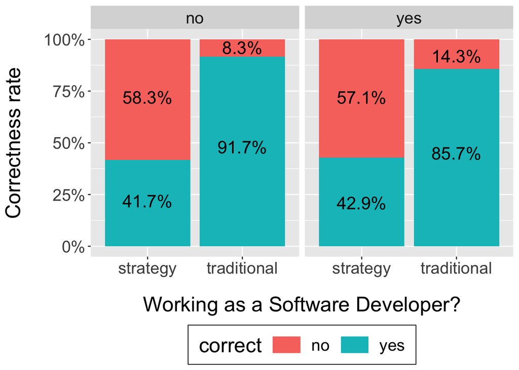

```r
# Summarising data for plotting

## Calculating correctness rate for participants who work
correctness.work.strategy <- ddply(sqldf ('SELECT * FROM `observations.nopretest.work` WHERE treatment = "strategy"'),
                                              work ~ treatment ~ correct,
                                              summarise,
                                              correctness = round ((length(correct) / 7) * 100, 1))

correctness.work.traditional <- ddply(sqldf ('SELECT * FROM `observations.nopretest.work` WHERE treatment = "traditional"'),
                                              work ~ treatment ~ correct,
                                              summarise,
                                              correctness = round ((length(correct) / 7) * 100, 1))


## Calculating correctness rate for participants who do not work
correctness.nowork.strategy <- ddply(sqldf ('SELECT * FROM `observations.nopretest.nowork` WHERE treatment = "strategy"'),
                                              work ~ treatment ~ correct,
                                              summarise,
                                              correctness = round ((length(correct) / 12) * 100, 1))

correctness.nowork.traditional <- ddply(sqldf ('SELECT * FROM `observations.nopretest.nowork` WHERE treatment = "traditional"'),
                                              work ~ treatment ~ correct,
                                              summarise,
                                              correctness = round ((length(correct) / 12) * 100, 1))

## Merging all summaries to create a single dataset
correctness.working.condition.df <- rbind (correctness.work.strategy,
                                        correctness.work.traditional,
                                        correctness.nowork.strategy,
                                        correctness.nowork.traditional)

# Ploting data
ggplot(
  correctness.working.condition.df,
  aes
    (
      y = correctness,
      x = treatment,
      fill = correct
      )
  ) +
  geom_bar(
    stat="identity",
    position = "stack"
  )  +
  facet_wrap (
    ~work
  ) +
  geom_text(
    aes(
      x = treatment,
      y = c (72, 21, 92, 45, 72, 22, 96, 48),
      label = paste0(correctness,"%")
    ),
    size=6
    # size=12
  ) +
theme(
    plot.title = element_text(hjust = 0.5, margin = margin(15, 0, 15, 0)),
    axis.title.y = element_text (margin = margin (0, 20, 0, 0)),
    axis.title.x = element_text (margin = margin (20, 0, 0, 0)),
    legend.position = "bottom",
    legend.box.background = element_rect(),
    legend.box.margin = margin (5, 5, 5, 5),
    legend.key.width = unit (1, "cm"),
    text = element_text(size=20)
    # text = element_text(size=40)
  ) +
  # ggtitle ("Effectiveness Analysis by Pretest/Post-test") +
  labs(
    x="Working as a Software Developer?",
    y="Correctness rate"
  ) +
  scale_y_continuous(labels = dollar_format (suffix = "%", prefix = ""))
```

### 3.5. Previous Experience With DP Analysis

> Plot

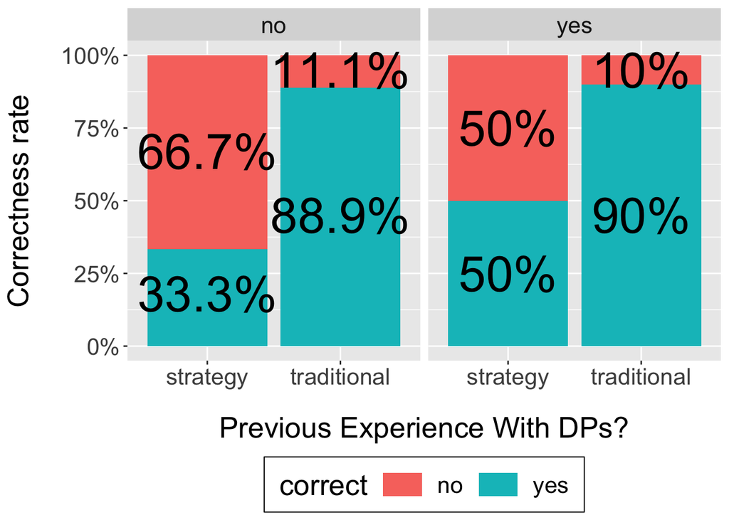

```r
# Summarising data for plotting

## Calculating correctness rate for participants who have previous experience
correctness.previousexperience.strategy <- ddply(sqldf ('SELECT * FROM `observations.nopretest.experiencedp` WHERE treatment = "strategy"'),
                                              patterns ~ treatment ~ correct,
                                              summarise,
                                              correctness = round ((length(correct) / 10) * 100, 1))

correctness.previousexperience.traditional <- ddply(sqldf ('SELECT * FROM `observations.nopretest.experiencedp` WHERE treatment = "traditional"'),
                                              patterns ~ treatment ~ correct,
                                              summarise,
                                              correctness = round ((length(correct) / 10) * 100, 1))


## Calculating correctness rate for participants who NO have previous experience
correctness.nopreviousexperience.strategy <- ddply(sqldf ('SELECT * FROM `observations.nopretest.noexperiencedp` WHERE treatment = "strategy"'),
                                              patterns ~ treatment ~ correct,
                                              summarise,
                                              correctness = round ((length(correct) / 9) * 100, 1))

correctness.nopreviousexperience.traditional <- ddply(sqldf ('SELECT * FROM `observations.nopretest.noexperiencedp` WHERE treatment = "traditional"'),
                                              patterns ~ treatment ~ correct,
                                              summarise,
                                              correctness = round ((length(correct) / 9) * 100, 1))

## Merging all summaries to create a single dataset
correctness.experiencedp.df <- rbind (correctness.previousexperience.strategy,
                                           correctness.previousexperience.traditional,
                                           correctness.nopreviousexperience.strategy,
                                           correctness.nopreviousexperience.traditional)

# Ploting data
ggplot(
  correctness.experiencedp.df,
  aes
    (
      y = correctness,
      x = treatment,
      fill = correct
      )
  ) +
  geom_bar(
    stat="identity",
    position = "stack"
  )  +
  facet_wrap (
    ~patterns
  ) +
  geom_text(
    aes(
      x = treatment,
      y = c (75, 25, 95, 45, 67, 18, 95, 45),
      label = paste0(correctness,"%")
    ),
    # size=6
    size=12
  ) +
theme(
    plot.title = element_text(hjust = 0.5, margin = margin(15, 0, 15, 0)),
    axis.title.y = element_text (margin = margin (0, 20, 0, 0)),
    axis.title.x = element_text (margin = margin (20, 0, 0, 0)),
    legend.position = "bottom",
    legend.box.background = element_rect(),
    legend.box.margin = margin (5, 5, 5, 5),
    legend.key.width = unit (1, "cm"),
    text = element_text(size=20)
    # text = element_text(size=40)
  ) +
  # ggtitle ("Effectiveness Analysis by Pretest/Post-test") +
  labs(
    x="Previous Experience With DPs?",
    y="Correctness rate"
  ) +
  scale_y_continuous(labels = dollar_format (suffix = "%", prefix = ""))
```